# **Problem Statement**

#### **Business Context**

Understanding customer personality and behavior is pivotal for businesses to enhance customer satisfaction and increase revenue. Segmentation based on a customer's personality, demographics, and purchasing behavior allows companies to create tailored marketing campaigns, improve customer retention, and optimize product offerings.

A leading retail company with a rapidly growing customer base seeks to gain deeper insights into their customers' profiles. The company recognizes that understanding customer personalities, lifestyles, and purchasing habits can unlock significant opportunities for personalizing marketing strategies and creating loyalty programs. These insights can help address critical business challenges, such as improving the effectiveness of marketing campaigns, identifying high-value customer groups, and fostering long-term relationships with customers.

With the competition intensifying in the retail space, moving away from generic strategies to more targeted and personalized approaches is essential for sustaining a competitive edge.

#### **Objective**

In an effort to optimize marketing efficiency and enhance customer experience, the company has embarked on a mission to identify distinct customer segments. By understanding the characteristics, preferences, and behaviors of each group, the company aims to:

1. Develop personalized marketing campaigns to increase conversion rates.
2. Create effective retention strategies for high-value customers.
3. Optimize resource allocation, such as inventory management, pricing strategies, and store layouts.

As a data scientist tasked with this project, your responsibility is to analyze the given customer data, apply machine learning techniques to segment the customer base, and provide actionable insights into the characteristics of each segment.

#### **Data Dictionary**

The dataset includes historical data on customer demographics, personality traits, and purchasing behaviors. Key attributes are:

1. **Customer Information**
   - **ID:** Unique identifier for each customer.
   - **Year_Birth:** Customer's year of birth.
   - **Education:** Education level of the customer.
   - **Marital_Status:** Marital status of the customer.
   - **Income:** Yearly household income (in dollars).
   - **Kidhome:** Number of children in the household.
   - **Teenhome:** Number of teenagers in the household.
   - **Dt_Customer:** Date when the customer enrolled with the company.
   - **Recency:** Number of days since the customer’s last purchase.
   - **Complain:** Whether the customer complained in the last 2 years (1 for yes, 0 for no).
2. **Spending Information (Last 2 Years)**
   - **MntWines:** Amount spent on wine.
   - **MntFruits:** Amount spent on fruits.
   - **MntMeatProducts:** Amount spent on meat.
   - **MntFishProducts:** Amount spent on fish.
   - **MntSweetProducts:** Amount spent on sweets.
   - **MntGoldProds:** Amount spent on gold products.
3. **Purchase and Campaign Interaction**
   - **NumDealsPurchases:** Number of purchases made using a discount.
   - **AcceptedCmp1:** Response to the 1st campaign (1 for yes, 0 for no).
   - **AcceptedCmp2:** Response to the 2nd campaign (1 for yes, 0 for no).
   - **AcceptedCmp3:** Response to the 3rd campaign (1 for yes, 0 for no).
   - **AcceptedCmp4:** Response to the 4th campaign (1 for yes, 0 for no).
   - **AcceptedCmp5:** Response to the 5th campaign (1 for yes, 0 for no).
   - **Response:** Response to the last campaign (1 for yes, 0 for no).
4. **Shopping Behavior**
   - **NumWebPurchases:** Number of purchases made through the company’s website.
   - **NumCatalogPurchases:** Number of purchases made using catalogs.
   - **NumStorePurchases:** Number of purchases made directly in stores.
   - **NumWebVisitsMonth:** Number of visits to the company’s website in the last month.

# **Code**

## **Importing necessary libraries**

```python
# Libraries to help with reading and manipulating data
import pandas as pd
import numpy as np

# Libaries to help with data visualization
import matplotlib.pyplot as plt
import seaborn as sns

# To scale the data
from sklearn.preprocessing import StandardScaler

# To compute distances
from scipy.spatial.distance import cdist, pdist

# To perform k-means clustering and compute silhouette scores
from sklearn.cluster import KMeans
from sklearn.metrics import silhouette_score

# To visualize the elbow curve and silhouette scores
from yellowbrick.cluster import KElbowVisualizer, SilhouetteVisualizer

# To suppress warnings
import warnings
warnings.filterwarnings("ignore")
```

## **Loading the data**

```python
from google.colab import drive
drive.mount('/content/drive')
```

```python
data = pd.read_csv("/content/drive/MyDrive/Colab Notebooks/MIT_ML_Projects/Customer_Personality_Segmentation/Customer_Personality_Segmentation.csv", sep="\t")
```

## **Data Overview**

```python
# Remove the limit for the number of displayed columns
pd.set_option("display.max_columns", None)

# Set the limit for the number of displayed rows
pd.set_option("display.max_rows", 200)
```

```python
data.shape
```

```
(2240, 29)
```

```python
data.head()
```

|  | ID | Year_Birth | Education | Marital_Status | Income | Kidhome | Teenhome | Dt_Customer | Recency | MntWines | MntFruits | MntMeatProducts | MntFishProducts | MntSweetProducts | MntGoldProds | NumDealsPurchases | NumWebPurchases | NumCatalogPurchases | NumStorePurchases | NumWebVisitsMonth | AcceptedCmp3 | AcceptedCmp4 | AcceptedCmp5 | AcceptedCmp1 | AcceptedCmp2 | Complain | Z_CostContact | Z_Revenue | Response |
| --- | --- | --- | --- | --- | --- | --- | --- | --- | --- | --- | --- | --- | --- | --- | --- | --- | --- | --- | --- | --- | --- | --- | --- | --- | --- | --- | --- | --- | --- |
| 0 | 5524 | 1957 | Graduation | Single | 58138.0 | 0 | 0 | 04-09-2012 | 58 | 635 | 88 | 546 | 172 | 88 | 88 | 3 | 8 | 10 | 4 | 7 | 0 | 0 | 0 | 0 | 0 | 0 | 3 | 11 | 1 |
| 1 | 2174 | 1954 | Graduation | Single | 46344.0 | 1 | 1 | 08-03-2014 | 38 | 11 | 1 | 6 | 2 | 1 | 6 | 2 | 1 | 1 | 2 | 5 | 0 | 0 | 0 | 0 | 0 | 0 | 3 | 11 | 0 |
| 2 | 4141 | 1965 | Graduation | Together | 71613.0 | 0 | 0 | 21-08-2013 | 26 | 426 | 49 | 127 | 111 | 21 | 42 | 1 | 8 | 2 | 10 | 4 | 0 | 0 | 0 | 0 | 0 | 0 | 3 | 11 | 0 |
| 3 | 6182 | 1984 | Graduation | Together | 26646.0 | 1 | 0 | 10-02-2014 | 26 | 11 | 4 | 20 | 10 | 3 | 5 | 2 | 2 | 0 | 4 | 6 | 0 | 0 | 0 | 0 | 0 | 0 | 3 | 11 | 0 |
| 4 | 5324 | 1981 | PhD | Married | 58293.0 | 1 | 0 | 19-01-2014 | 94 | 173 | 43 | 118 | 46 | 27 | 15 | 5 | 5 | 3 | 6 | 5 | 0 | 0 | 0 | 0 | 0 | 0 | 3 | 11 | 0 |

```python
data.tail()
```

|  | ID | Year_Birth | Education | Marital_Status | Income | Kidhome | Teenhome | Dt_Customer | Recency | MntWines | MntFruits | MntMeatProducts | MntFishProducts | MntSweetProducts | MntGoldProds | NumDealsPurchases | NumWebPurchases | NumCatalogPurchases | NumStorePurchases | NumWebVisitsMonth | AcceptedCmp3 | AcceptedCmp4 | AcceptedCmp5 | AcceptedCmp1 | AcceptedCmp2 | Complain | Z_CostContact | Z_Revenue | Response |
| --- | --- | --- | --- | --- | --- | --- | --- | --- | --- | --- | --- | --- | --- | --- | --- | --- | --- | --- | --- | --- | --- | --- | --- | --- | --- | --- | --- | --- | --- |
| 2235 | 10870 | 1967 | Graduation | Married | 61223.0 | 0 | 1 | 13-06-2013 | 46 | 709 | 43 | 182 | 42 | 118 | 247 | 2 | 9 | 3 | 4 | 5 | 0 | 0 | 0 | 0 | 0 | 0 | 3 | 11 | 0 |
| 2236 | 4001 | 1946 | PhD | Together | 64014.0 | 2 | 1 | 10-06-2014 | 56 | 406 | 0 | 30 | 0 | 0 | 8 | 7 | 8 | 2 | 5 | 7 | 0 | 0 | 0 | 1 | 0 | 0 | 3 | 11 | 0 |
| 2237 | 7270 | 1981 | Graduation | Divorced | 56981.0 | 0 | 0 | 25-01-2014 | 91 | 908 | 48 | 217 | 32 | 12 | 24 | 1 | 2 | 3 | 13 | 6 | 0 | 1 | 0 | 0 | 0 | 0 | 3 | 11 | 0 |
| 2238 | 8235 | 1956 | Master | Together | 69245.0 | 0 | 1 | 24-01-2014 | 8 | 428 | 30 | 214 | 80 | 30 | 61 | 2 | 6 | 5 | 10 | 3 | 0 | 0 | 0 | 0 | 0 | 0 | 3 | 11 | 0 |
| 2239 | 9405 | 1954 | PhD | Married | 52869.0 | 1 | 1 | 15-10-2012 | 40 | 84 | 3 | 61 | 2 | 1 | 21 | 3 | 3 | 1 | 4 | 7 | 0 | 0 | 0 | 0 | 0 | 0 | 3 | 11 | 1 |

```python
data.nunique()
```

|  | 0 |
| --- | --- |
| ID | 2240 |
| Year_Birth | 59 |
| Education | 5 |
| Marital_Status | 8 |
| Income | 1974 |
| Kidhome | 3 |
| Teenhome | 3 |
| Dt_Customer | 663 |
| Recency | 100 |
| MntWines | 776 |
| MntFruits | 158 |
| MntMeatProducts | 558 |
| MntFishProducts | 182 |
| MntSweetProducts | 177 |
| MntGoldProds | 213 |
| NumDealsPurchases | 15 |
| NumWebPurchases | 15 |
| NumCatalogPurchases | 14 |
| NumStorePurchases | 14 |
| NumWebVisitsMonth | 16 |
| AcceptedCmp3 | 2 |
| AcceptedCmp4 | 2 |
| AcceptedCmp5 | 2 |
| AcceptedCmp1 | 2 |
| AcceptedCmp2 | 2 |
| Complain | 2 |
| Z_CostContact | 1 |
| Z_Revenue | 1 |
| Response | 2 |

**dtype:** int64

```python
data.info()
```

```
<class 'pandas.core.frame.DataFrame'>
RangeIndex: 2240 entries, 0 to 2239
Data columns (total 29 columns):
 #   Column               Non-Null Count  Dtype
---  ------               --------------  -----
 0   ID                   2240 non-null   int64
 1   Year_Birth           2240 non-null   int64
 2   Education            2240 non-null   object
 3   Marital_Status       2240 non-null   object
 4   Income               2216 non-null   float64
 5   Kidhome              2240 non-null   int64
 6   Teenhome             2240 non-null   int64
 7   Dt_Customer          2240 non-null   object
 8   Recency              2240 non-null   int64
 9   MntWines             2240 non-null   int64
```

[output cut: 21 more lines]

```python
data.describe().T
```

|  | count | mean | std | min | 25% | 50% | 75% | max |
| --- | --- | --- | --- | --- | --- | --- | --- | --- |
| ID | 2240.0 | 5592.159821 | 3246.662198 | 0.0 | 2828.25 | 5458.5 | 8427.75 | 11191.0 |
| Year_Birth | 2240.0 | 1968.805804 | 11.984069 | 1893.0 | 1959.00 | 1970.0 | 1977.00 | 1996.0 |
| Income | 2216.0 | 52247.251354 | 25173.076661 | 1730.0 | 35303.00 | 51381.5 | 68522.00 | 666666.0 |
| Kidhome | 2240.0 | 0.444196 | 0.538398 | 0.0 | 0.00 | 0.0 | 1.00 | 2.0 |
| Teenhome | 2240.0 | 0.506250 | 0.544538 | 0.0 | 0.00 | 0.0 | 1.00 | 2.0 |
| Recency | 2240.0 | 49.109375 | 28.962453 | 0.0 | 24.00 | 49.0 | 74.00 | 99.0 |
| MntWines | 2240.0 | 303.935714 | 336.597393 | 0.0 | 23.75 | 173.5 | 504.25 | 1493.0 |
| MntFruits | 2240.0 | 26.302232 | 39.773434 | 0.0 | 1.00 | 8.0 | 33.00 | 199.0 |
| MntMeatProducts | 2240.0 | 166.950000 | 225.715373 | 0.0 | 16.00 | 67.0 | 232.00 | 1725.0 |
| MntFishProducts | 2240.0 | 37.525446 | 54.628979 | 0.0 | 3.00 | 12.0 | 50.00 | 259.0 |
| MntSweetProducts | 2240.0 | 27.062946 | 41.280498 | 0.0 | 1.00 | 8.0 | 33.00 | 263.0 |
| MntGoldProds | 2240.0 | 44.021875 | 52.167439 | 0.0 | 9.00 | 24.0 | 56.00 | 362.0 |
| NumDealsPurchases | 2240.0 | 2.325000 | 1.932238 | 0.0 | 1.00 | 2.0 | 3.00 | 15.0 |
| NumWebPurchases | 2240.0 | 4.084821 | 2.778714 | 0.0 | 2.00 | 4.0 | 6.00 | 27.0 |
| NumCatalogPurchases | 2240.0 | 2.662054 | 2.923101 | 0.0 | 0.00 | 2.0 | 4.00 | 28.0 |
| NumStorePurchases | 2240.0 | 5.790179 | 3.250958 | 0.0 | 3.00 | 5.0 | 8.00 | 13.0 |
| NumWebVisitsMonth | 2240.0 | 5.316518 | 2.426645 | 0.0 | 3.00 | 6.0 | 7.00 | 20.0 |
| AcceptedCmp3 | 2240.0 | 0.072768 | 0.259813 | 0.0 | 0.00 | 0.0 | 0.00 | 1.0 |
| AcceptedCmp4 | 2240.0 | 0.074554 | 0.262728 | 0.0 | 0.00 | 0.0 | 0.00 | 1.0 |
| AcceptedCmp5 | 2240.0 | 0.072768 | 0.259813 | 0.0 | 0.00 | 0.0 | 0.00 | 1.0 |
| AcceptedCmp1 | 2240.0 | 0.064286 | 0.245316 | 0.0 | 0.00 | 0.0 | 0.00 | 1.0 |
| AcceptedCmp2 | 2240.0 | 0.013393 | 0.114976 | 0.0 | 0.00 | 0.0 | 0.00 | 1.0 |
| Complain | 2240.0 | 0.009375 | 0.096391 | 0.0 | 0.00 | 0.0 | 0.00 | 1.0 |
| Z_CostContact | 2240.0 | 3.000000 | 0.000000 | 3.0 | 3.00 | 3.0 | 3.00 | 3.0 |
| Z_Revenue | 2240.0 | 11.000000 | 0.000000 | 11.0 | 11.00 | 11.0 | 11.00 | 11.0 |
| Response | 2240.0 | 0.149107 | 0.356274 | 0.0 | 0.00 | 0.0 | 0.00 | 1.0 |

```python
data.duplicated().sum()
```

```
np.int64(0)
```

```python
data.isnull().sum()
```

|  | 0 |
| --- | --- |
| ID | 0 |
| Year_Birth | 0 |
| Education | 0 |
| Marital_Status | 0 |
| Income | 24 |
| Kidhome | 0 |
| Teenhome | 0 |
| Dt_Customer | 0 |
| Recency | 0 |
| MntWines | 0 |
| MntFruits | 0 |
| MntMeatProducts | 0 |
| MntFishProducts | 0 |
| MntSweetProducts | 0 |
| MntGoldProds | 0 |
| NumDealsPurchases | 0 |
| NumWebPurchases | 0 |
| NumCatalogPurchases | 0 |
| NumStorePurchases | 0 |
| NumWebVisitsMonth | 0 |
| AcceptedCmp3 | 0 |
| AcceptedCmp4 | 0 |
| AcceptedCmp5 | 0 |
| AcceptedCmp1 | 0 |
| AcceptedCmp2 | 0 |
| Complain | 0 |
| Z_CostContact | 0 |
| Z_Revenue | 0 |
| Response | 0 |

**dtype:** int64

**Observations:**

- Dataset contains 2,240 rows and 29 columns
- Income contains some null/missing values that need to be treated
- ID, Z_CostContact, and Z_Revenue can be dropped
- Average household income is around $52,000

## **Data Cleaning**

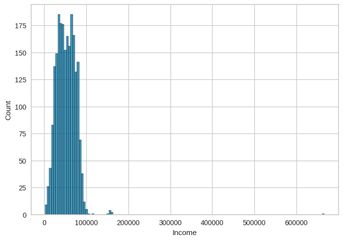

```python
sns.histplot(data['Income'])
```

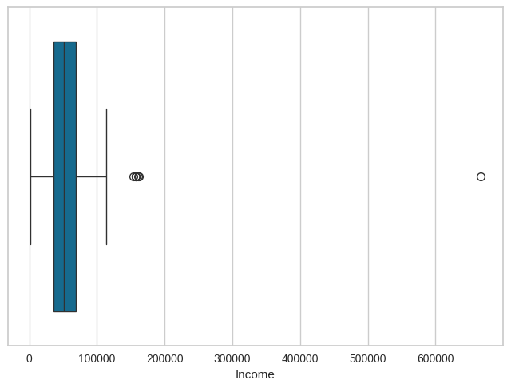

```python
sns.boxplot(x = data['Income'])
```

```python
data['Income'].fillna(data['Income'].median(), inplace=True)
```

```python
data.drop(['ID', 'Z_CostContact', 'Z_Revenue'], axis=1, inplace=True)
```

```python
# Convert the string dates into pandas datetime
data['Dt_Customer'] = pd.to_datetime(
    data['Dt_Customer'],
    format='%d-%m-%Y'
)

# Compute the days since joined from Dt_Customer
today = pd.Timestamp('today').normalize()
data['Days_Since_Joined'] = (today - data['Dt_Customer']).dt.days

# Sanity check
data[['Dt_Customer', 'Days_Since_Joined']].head()


data.drop(['Dt_Customer'], axis=1, inplace=True)
```

```python
data.head()
```

|  | Year_Birth | Education | Marital_Status | Income | Kidhome | Teenhome | Recency | MntWines | MntFruits | MntMeatProducts | MntFishProducts | MntSweetProducts | MntGoldProds | NumDealsPurchases | NumWebPurchases | NumCatalogPurchases | NumStorePurchases | NumWebVisitsMonth | AcceptedCmp3 | AcceptedCmp4 | AcceptedCmp5 | AcceptedCmp1 | AcceptedCmp2 | Complain | Response | Days_Since_Joined |
| --- | --- | --- | --- | --- | --- | --- | --- | --- | --- | --- | --- | --- | --- | --- | --- | --- | --- | --- | --- | --- | --- | --- | --- | --- | --- | --- |
| 0 | 1957 | Graduation | Single | 58138.0 | 0 | 0 | 58 | 635 | 88 | 546 | 172 | 88 | 88 | 3 | 8 | 10 | 4 | 7 | 0 | 0 | 0 | 0 | 0 | 0 | 1 | 4685 |
| 1 | 1954 | Graduation | Single | 46344.0 | 1 | 1 | 38 | 11 | 1 | 6 | 2 | 1 | 6 | 2 | 1 | 1 | 2 | 5 | 0 | 0 | 0 | 0 | 0 | 0 | 0 | 4135 |
| 2 | 1965 | Graduation | Together | 71613.0 | 0 | 0 | 26 | 426 | 49 | 127 | 111 | 21 | 42 | 1 | 8 | 2 | 10 | 4 | 0 | 0 | 0 | 0 | 0 | 0 | 0 | 4334 |
| 3 | 1984 | Graduation | Together | 26646.0 | 1 | 0 | 26 | 11 | 4 | 20 | 10 | 3 | 5 | 2 | 2 | 0 | 4 | 6 | 0 | 0 | 0 | 0 | 0 | 0 | 0 | 4161 |
| 4 | 1981 | PhD | Married | 58293.0 | 1 | 0 | 94 | 173 | 43 | 118 | 46 | 27 | 15 | 5 | 5 | 3 | 6 | 5 | 0 | 0 | 0 | 0 | 0 | 0 | 0 | 4183 |

**Summary:**

- After analyzing the distribution of the Income variable, we observed that it was slightly right-skewed and contained some outliers. Therefore we chose to impute the missing values using the median, which is more robust to outliers than the mean. (Alternatively, since the missing values only made up 1% of the data it could have also been dropped)
- The ID column was dropped because ID carries no useful infromation for clustering and
- The Z_CostContact, and Z_Revenue columns were dropped because they both contained only one unique value across rows which offered no varianace or discrminative power for clustering
- The Dt_Customer column was converted to a new feature Days_Since_Joined which better supports clustering and time-based analysis
- The orginal Dt_Customer column was dropped

## **Univariate Analysis**

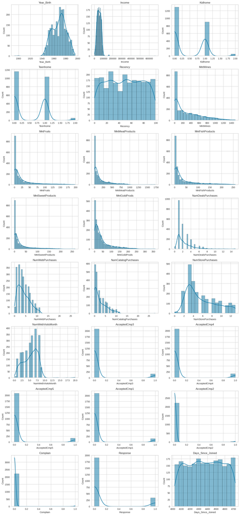

```python
import math

# Select the numeric columns
numeric_cols = data.select_dtypes(include='number').columns

# Set up the grid size
n_cols = 3
n_rows = math.ceil(len(numeric_cols)/n_cols)
plt.figure(figsize=(n_cols * 5, n_rows * 4))

# Loop through the numeric columns and display their histograms
for i, col in enumerate(numeric_cols, 1):
    plt.subplot(n_rows, n_cols, i)
    sns.histplot(data[col], kde=True)
    plt.title(col)
    plt.tight_layout()

plt.show()
```

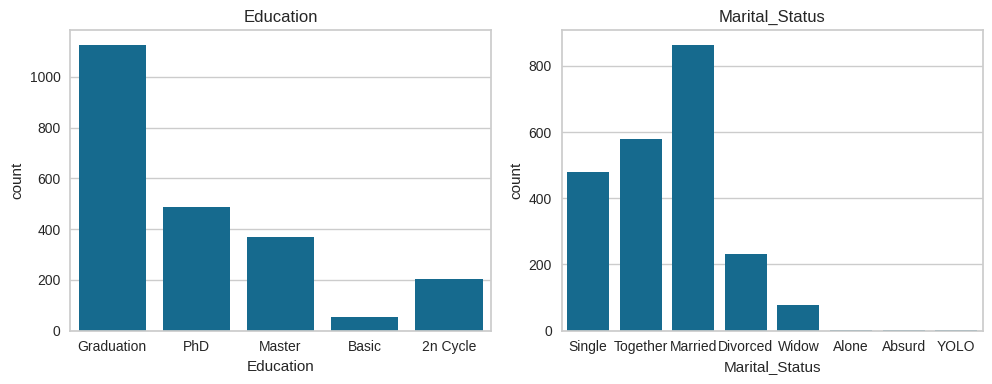

```python
# Select the categorical columns
cat_cols = data.select_dtypes(include=['object']).columns

# Set up the grid size
n_cols = 3
n_rows = math.ceil(len(cat_cols)/n_cols)
plt.figure(figsize=(n_cols * 5, n_rows * 4))

# Loop through the categorical columns and display their countplots
for i, col in enumerate(cat_cols, 1):
    plt.subplot(n_rows, n_cols, i)
    sns.countplot(x=col, data=data)
    plt.title(col)
    plt.tight_layout()

plt.show()
```

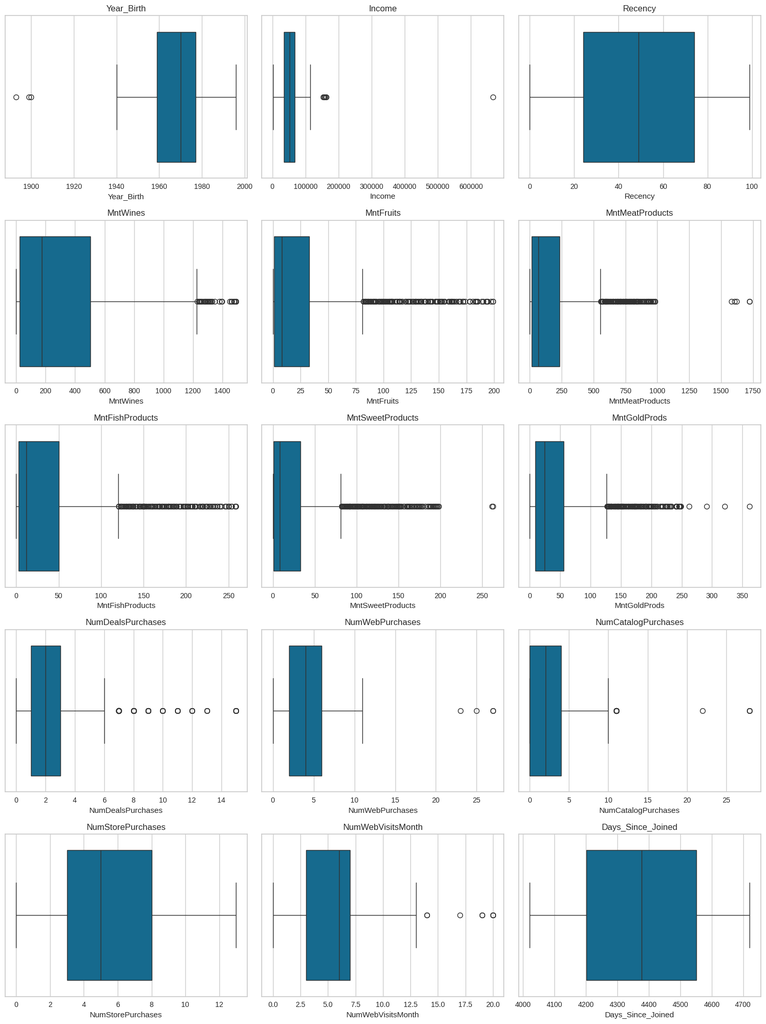

```python
# Select the numeric columns with > 3 unique values
filtered_numeric_cols = [col for col in numeric_cols if data[col].nunique() > 3]

# Set up the grid size
n_cols = 3
n_rows = math.ceil(len(filtered_numeric_cols)/n_cols)
plt.figure(figsize=(n_cols * 5, n_rows * 4))

# Loop through the numeric columns and display their boxplots
for i, col in enumerate(filtered_numeric_cols, 1):
    plt.subplot(n_rows, n_cols, i)
    sns.boxplot(x=data[col])
    plt.title(col)
    plt.tight_layout()

plt.show()
```

**Observations:**

- Days Since Joined appears to follow a uniform distribution, suggesting it may not offer strong clustering value
- Majority of customers are Married
- Majority of customers fall under 'Graduation' category in the Education column
- Number of store purchases are generally higher than web purchases
- The Kidhome variable is split approximately 60/40 between households with 0 and 1 child, respectively
- The Teenhome variable shows an even split, with around 50% of customers having 0 or 1 teenager at home.

## **Bivariate Analysis**

```python
# Select the numeric columns
numeric_df = data.select_dtypes(include='number')
```

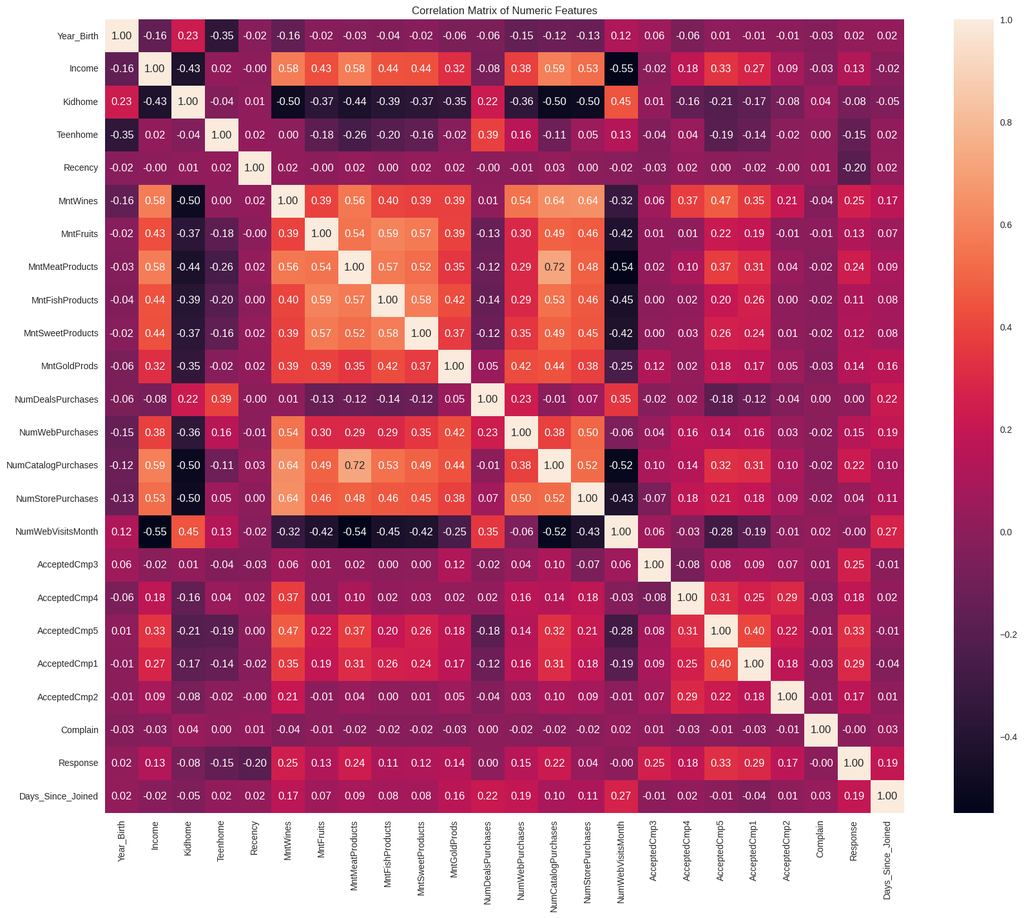

```python
plt.figure(figsize=(20, 16))
sns.heatmap(numeric_df.corr(), fmt=".2f", annot=True)
plt.title('Correlation Matrix of Numeric Features')
plt.show()
```

**Observations:**

## Principal Component Analysis

```python
# Selected the features that provided the most insight into data for clustering
selected_features = data[['Income', 'Kidhome', 'NumWebVisitsMonth', 'NumStorePurchases', 'NumCatalogPurchases', 'NumWebPurchases', 'MntMeatProducts', 'MntGoldProds']]
```

```python
# Scale features
scaler = StandardScaler()
scaled_data = scaler.fit_transform(selected_features)
```

```python
# Apply PCA
from sklearn.decomposition import PCA

pca = PCA()
pca.fit(scaled_data)
```

```
PCA()
```

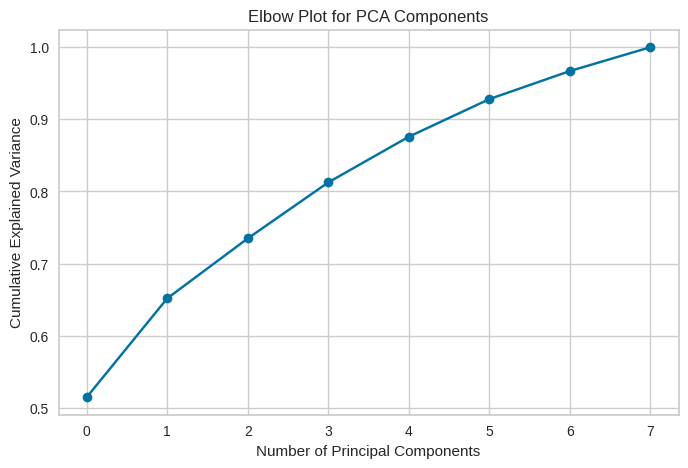

```python
# Plot to see the relationship between PCA Components and data variance
plt.figure(figsize=(8, 5))
plt.plot(np.cumsum(pca.explained_variance_ratio_), marker='o')
plt.xlabel('Number of Principal Components')
plt.ylabel('Cumulative Explained Variance')
plt.title('Elbow Plot for PCA Components')
plt.grid(True)
plt.show()
```

```python
# Keep enough components for 80% of variance
pca = PCA(n_components=0.80)
pca_data = pca.fit_transform(scaled_data)
```

## **K-means Clustering**

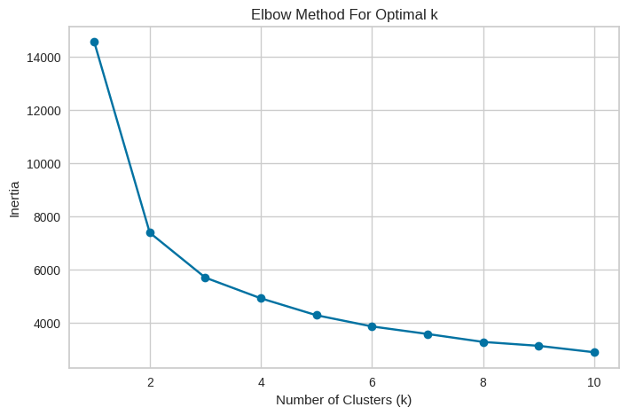

```python
selected_data = pca_data

inertia = []
k_range = range(1, 11)

# Loop through the different values of K
for k in k_range:
    kmeans = KMeans(n_clusters=k, random_state=1)
    kmeans.fit(selected_data)
    inertia.append(kmeans.inertia_)

# Create Elbow plot to find optimal K
plt.figure(figsize=(8, 5))
plt.plot(k_range, inertia, marker='o')
plt.xlabel('Number of Clusters (k)')
plt.ylabel('Inertia')
plt.title('Elbow Method For Optimal k')
plt.grid(True)
plt.show()
```

```python
from sklearn.metrics import silhouette_score

# Check which K had the highest silhoutte score
for k in [2, 3, 4, 5]:
    kmeans = KMeans(n_clusters=k, random_state=42).fit(selected_data)
    score = silhouette_score(selected_data, kmeans.labels_)
    print(f"k={k}, silhouette score: {score:.3f}")
```

```
k=2, silhouette score: 0.446
k=3, silhouette score: 0.386
k=4, silhouette score: 0.346
k=5, silhouette score: 0.347
```

**Summary:**

- Decided to use 2 clusters

```python
# Use the KMeans algorithm with 2 clusters
kmeans_final = KMeans(n_clusters=2, random_state=1)
kmeans_final.fit(selected_data)

# Add a new column to the data that indicates which cluster each row belongs to
cluster_labels = kmeans_final.labels_
data['Cluster'] = cluster_labels
```

```python
data['Cluster'].value_counts()
```

| Cluster | count |
| --- | --- |
| 1 | 1225 |
| 0 | 1015 |

**dtype:** int64

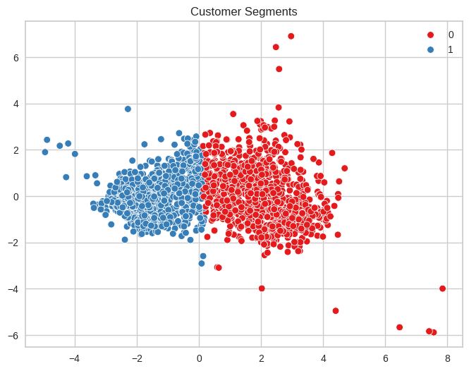

```python
import seaborn as sns

# Plot the clusters
plt.figure(figsize=(8, 6))
sns.scatterplot(x=selected_data[:, 0], y=selected_data[:, 1], hue=cluster_labels, palette='Set1')
plt.title('Customer Segments')
plt.grid(True)
plt.show()
```

## **Cluster Profiling and Comparison**

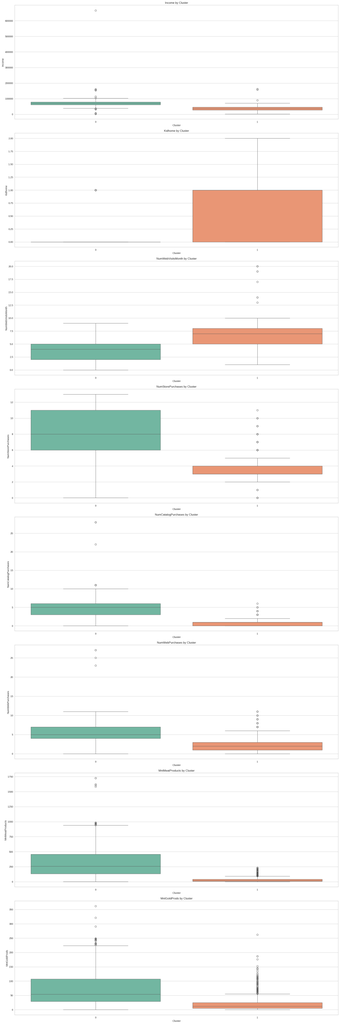

```python
# Assign the cluster labels from the model to the dataset
data['Cluster'] = kmeans_final.labels_

# Select key features to profile across clusters
profile_vars = ['Income', 'Kidhome', 'NumWebVisitsMonth', 'NumStorePurchases', 'NumCatalogPurchases', 'NumWebPurchases', 'MntMeatProducts', 'MntGoldProds']

import seaborn as sns
import matplotlib.pyplot as plt

plt.figure(figsize=(20, 60))

# Loop through the selected features and create a boxplot by cluster
for i, col in enumerate(profile_vars):
    plt.subplot(len(profile_vars), 1, i + 1)
    sns.boxplot(data=data, x='Cluster', y=col, palette='Set2')
    plt.title(f'{col} by Cluster')
    plt.tight_layout()

plt.show()
```

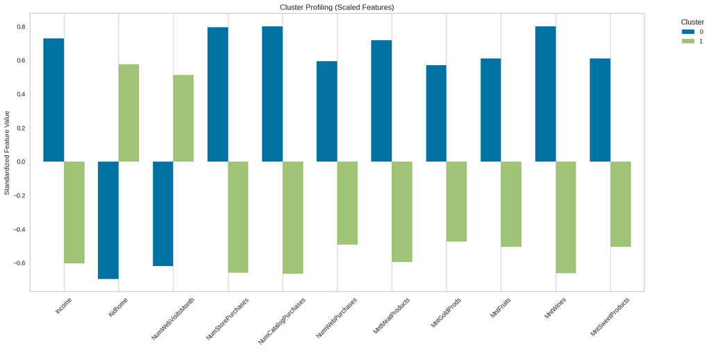

```python
# Scale select features
profile_vars = ['Income','Kidhome', 'NumWebVisitsMonth', 'NumStorePurchases', 'NumCatalogPurchases', 'NumWebPurchases', 'MntMeatProducts', 'MntGoldProds', 'MntFruits', 'MntWines', 'MntSweetProducts']
scaler = StandardScaler()
scaled_features = scaler.fit_transform(data[profile_vars])

# Create a dataframe with scaled values + cluster labels
scaled_df = pd.DataFrame(scaled_features, columns=profile_vars)
scaled_df['Cluster'] = data['Cluster']

# Group and average
scaled_summary = scaled_df.groupby('Cluster').mean().T

# Plot
scaled_summary.plot(kind='bar', figsize=(16, 8), width=0.75)
plt.title('Cluster Profiling (Scaled Features)')
plt.ylabel('Standardized Feature Value')
plt.xticks(rotation=45)
plt.grid(axis='y')
plt.legend(title='Cluster', bbox_to_anchor=(1.05, 1), loc='upper left')
plt.tight_layout()
plt.show()
```

##### **Observations:**

Cluster 0:

- High Income
- Fewer children
- Above average spending across meat & gold products
- High active across all purchasing channels
- Above average catalog purchases

*These are the premium high engagment customers*

Cluster 1:

- Low income
- More children
- Below average spend on products
- Lower activity in all shopping channels
- Higher web visits below average store purchases

*These are the budget-conscious lower-engagement customers and have more kids*

## **Business Recommendations**

**For Cluster 0:** The store should reward their high engagement and aim to retain these high value customers with something like a loyalty program and rewards/perks. They also respond well to catalogs.